# Data Camp Python Notes (Visualization)

davegoblue

September 2, 2017

## Background and Overview

DataCamp offer interactive courses related to Python Programming. Since R Markdown documents can run simple Python code chunks (though the data is not accessible to future chunks, a large difference from R Markdown for R), this document attempts to summarize notes from the modules when possible.

Topic areas summarized include:

- Python Programming (Introduction, Intermediate, Toolbox I/II, Network Analysis I/II)
- Python Import and Clean Data (Import I/II, Clean)
- Python Data Manipulation (pandas Foundations, Manipulating DF with pandas, Merging DF with pandas, Databases in pandas, Data Types)
- Python Visualization (Introduction to Python Data Visualization, Interactive Visualization with Bokeh)
- Python Statistics (Statistical Thinking in Python Parts I/II)
- Python Machine Learning ()

The complete version as of July 31, 2017 has been archived as DataCamp_PythonNotes_v001. Archive files for DataCamp_Python_ImportClean_v002 and DataCamp_Python_Programming_v002 have also been created to contain summaries of those areas. Further, DataCamp_PythonNotes_v002 was created for capturing summaries of additional topics.

The version of DataCamp_PythonNotes_v002 as of September 1, 2017 has been archived. Archive files for DataCamp_Python_DataManipulation_v003 and DataCamp_Python_Visualization_v003 have also been created to contain summaries of these areas. Further, DataCamp_PythonNotes_v003 was created for capturing summaries of additional topics.

This document includes:

- Python Visualization (Introduction to Python Data Visualization, Interactive Visualization with Bokeh)

## Python Visualization

### *Introduction to Data Visualization with Python*

Chapter 1 - Data Ingestion and Inspection

Plotting multiple graphs - suppose that you have measurements time, Temperature, and DewPoint:

- With “import matplotlib.pyplot as plt”, then plt.plot() works on numpy arrays, lists, pandas DataSeries
  - plt.plot(time, Temperature, “red”)
  - plt.plot(time, DewPoint, “red”) # overlays the curve on the same axes
  - plt.xlabel(“Date”) ; plt.title(“Temperature & Dew Point”)
  - plt.show() # shows the figure on screen
- The plt.axes([]) commands will both establish axes and ask that the next curve(s) be drawn on those axes
  - plt.axes([0.05, 0.05, 0.425, 0.9]) # sets up the axes for a first plot
  - plt. # things to be drawn on this axis
  - plt.axes([0.525, 0.05, 0.425, 0.9]) # sets up the axes for a second plot
  - plt. # things to be drawn on this axis
  - plt.show() # shows the figure on the screen
- The commands inside plt.axes([x_lo, y_lo, width, height]) will “sometimes require some trial and error to get right”
  - The x_lo of 0.05 means 5% of the way to the right of the “full screen” while the width of 0.425 means 42.5% of the “full screen”, so draw from 5% to 47.5% of “full-screen width”
- Conversely, the suplot() command will create multiple axes without the need for this type of customization
  - plt.subplot(nrows, ncols, thisSubPlot) # sets up a grid of nrows x ncols; activates thisSubPlot which will be active until next call of plt.subplot() - across rows, then down columns, indexed from 1 (not 0)
  - plt.tight_layout() # helps avoid tick overlap and excessive white-space

Customizing axes - making the plots less messy and more appealing:

- The plt.axis([xmin, xmax, ymin, ymax]) will control the zoom of the x/y components of the axis
  - Alternately, plt.xlim([xmin, xmax]) will control just the x-axis limits
  - Alternately, plt.ylim([ymin, ymax]) will control just the y-axis limits
  - Arguments can be passed as tuples or as lists - xlim((-2, 3)) and xlim([-2, 3]) do the same thing
  - Interestingly, if just the xlim() is provided, then the ylim() will default to what is best for the full plot (including things not in xlim), so it may nonetheless be necessary to provide a ylim()
- There are other commands available to plt.axis(), including
  - axis(“off”) - turns off axis lines, labels
  - axis(“equal”) - equal scaling on x, y axes
  - axis(“square”) - forces square plot
  - axis(“tight”) - sets xlim() and ylim() to show all the data

Legends, annotations, and styles:

- Legends - provide labels for overlaid points and curves
  - Can be passed as part of the plotting command, such as plt.scatter(x, y, marker=“o”, color=“red”, label=“setosa”)
  - The legend is then created using plt.legend(loc=“upper right”) # loc can be set to other areas to move the legend - default is “best”
- Annotations - text labels, including optionally arrows from the text to other components of the graph
  - plt.annotate(“myText”, xy=(x, y)) # will place “myText” at location x, y
  - Additional options are xytext (coordinates of label) or arrowprops (controls drawing of arrow)
  - plt.annotate(“myText”, xy=(x, y), xytext=(x1, y1), arrowprops={“color”:“red”}) # will place “myText” at location x1, y1 and draw a red arrow to point x, y
  - Often requires some experimentation to get to a visually pleasing plot
- Styles - controlled by the default style sheets in Matplotlib
  - Can switch between styles using plt.style.use() # ggplot is an option, so plt.style.use(“ggplot”) ; fivethirtyeight is an option, so plt.style.use(“fivethirtyeight”)
  - Can see what styles are available with plt.style.available

Example code includes:

```python
year = [1970, 1971, 1972, 1973, 1974, 1975, 1976, 1977, 1978, 1979, 1980, 1981, 1982, 1983, 1984, 1985, 1986, 1987, 1988, 1989, 1990, 1991, 1992, 1993, 1994, 1995, 1996, 1997, 1998, 1999, 2000, 2001, 2002, 2003, 2004, 2005, 2006, 2007, 2008, 2009, 2010, 2011]
physical_sciences = [13.800000000000001, 14.9, 14.800000000000001, 16.5, 18.199999999999999, 19.100000000000001, 20.0, 21.300000000000001, 22.5, 23.699999999999999, 24.600000000000001, 25.699999999999999, 27.300000000000001, 27.600000000000001, 28.0, 27.5, 28.399999999999999, 30.399999999999999, 29.699999999999999, 31.300000000000001, 31.600000000000001, 32.600000000000001, 32.600000000000001, 33.600000000000001, 34.799999999999997, 35.899999999999999, 37.299999999999997, 38.299999999999997, 39.700000000000003, 40.200000000000003, 41.0, 42.200000000000003, 41.100000000000001, 41.700000000000003, 42.100000000000001, 41.600000000000001, 40.799999999999997, 40.700000000000003, 40.700000000000003, 40.700000000000003, 40.200000000000003, 40.100000000000001]
computer_science = [13.6, 13.6, 14.9, 16.399999999999999, 18.899999999999999, 19.800000000000001, 23.899999999999999, 25.699999999999999, 28.100000000000001, 30.199999999999999, 32.5, 34.799999999999997, 36.299999999999997, 37.100000000000001, 36.799999999999997, 35.700000000000003, 34.700000000000003, 32.399999999999999, 30.800000000000001, 29.899999999999999, 29.399999999999999, 28.699999999999999, 28.199999999999999, 28.5, 28.5, 27.5, 27.100000000000001, 26.800000000000001, 27.0, 28.100000000000001, 27.699999999999999, 27.600000000000001, 27.0, 25.100000000000001, 22.199999999999999, 20.600000000000001, 18.600000000000001, 17.600000000000001, 17.800000000000001, 18.100000000000001, 17.600000000000001, 18.199999999999999]

# Import matplotlib.pyplot
import matplotlib.pyplot as plt

# Plot in blue the % of degrees awarded to women in the Physical Sciences
plt.plot(year, physical_sciences, color='blue')

# Plot in red the % of degrees awarded to women in Computer Science
plt.plot(year, computer_science, color='red')

# Display the plot
# plt.show()
plt.savefig("_dummyPy110.png", bbox_inches="tight")
plt.clf()


# Create plot axes for the first line plot
plt.axes([0.05, 0.05, 0.425, 0.9])

# Plot in blue the % of degrees awarded to women in the Physical Sciences
plt.plot(year, physical_sciences, color='blue')

# Create plot axes for the second line plot
plt.axes([0.525, 0.05, 0.425, 0.9])

# Plot in red the % of degrees awarded to women in Computer Science
plt.plot(year, computer_science, color='red')

# Display the plot
# plt.show()
plt.savefig("_dummyPy111.png", bbox_inches="tight")
plt.clf()


# Create a figure with 1x2 subplot and make the left subplot active
plt.subplot(1, 2, 1)

# Plot in blue the % of degrees awarded to women in the Physical Sciences
plt.plot(year, physical_sciences, color='blue')
plt.title('Physical Sciences')

# Make the right subplot active in the current 1x2 subplot grid
plt.subplot(1, 2, 2)

# Plot in red the % of degrees awarded to women in Computer Science
plt.plot(year, computer_science, color='red')
plt.title('Computer Science')

# Use plt.tight_layout() to improve the spacing between subplots
plt.tight_layout()
# plt.show()
plt.savefig("_dummyPy112.png", bbox_inches="tight")
plt.clf()


health = [77.099999999999994, 75.5, 76.900000000000006, 77.400000000000006, 77.900000000000006, 78.900000000000006, 79.200000000000003, 80.5, 81.900000000000006, 82.299999999999997, 83.5, 84.099999999999994, 84.400000000000006, 84.599999999999994, 85.099999999999994, 85.299999999999997, 85.700000000000003, 85.5, 85.200000000000003, 84.599999999999994, 83.900000000000006, 83.5, 83.0, 82.400000000000006, 81.799999999999997, 81.5, 81.299999999999997, 81.900000000000006, 82.099999999999994, 83.5, 83.5, 85.099999999999994, 85.799999999999997, 86.5, 86.5, 86.0, 85.900000000000006, 85.400000000000006, 85.200000000000003, 85.099999999999994, 85.0, 84.799999999999997]
education = [74.535327580000001, 74.149203689999993, 73.554519959999993, 73.501814429999996, 73.336811429999997, 72.801854480000003, 72.166524710000004, 72.456394810000006, 73.192821339999995, 73.821142339999994, 74.981031520000002, 75.845123450000003, 75.843649139999997, 75.950601230000004, 75.869116009999999, 75.923439709999997, 76.143015160000004, 76.963091680000005, 77.627661770000003, 78.111918720000006, 78.866858590000007, 78.991245969999994, 78.435181909999997, 77.267311989999996, 75.814932639999995, 75.125256210000003, 75.035199210000002, 75.163701299999985, 75.486160269999999, 75.838162060000002, 76.692142840000002, 77.375229309999995, 78.644243939999996, 78.544948149999996, 78.65074774, 79.067121729999997, 78.686305509999997, 78.72141311, 79.196326740000003, 79.532908700000007, 79.618624510000004, 79.432811839999999]

# Create a figure with 2x2 subplot layout and make the top left subplot active
plt.subplot(2, 2, 1)

# Plot in blue the % of degrees awarded to women in the Physical Sciences
plt.plot(year, physical_sciences, color='blue')
plt.title('Physical Sciences')

# Make the top right subplot active in the current 2x2 subplot grid
plt.subplot(2, 2, 2)

# Plot in red the % of degrees awarded to women in Computer Science
plt.plot(year, computer_science, color='red')
plt.title('Computer Science')

# Make the bottom left subplot active in the current 2x2 subplot grid
plt.subplot(2, 2, 3)

# Plot in green the % of degrees awarded to women in Health Professions
plt.plot(year, health, color='green')
plt.title('Health Professions')

# Make the bottom right subplot active in the current 2x2 subplot grid
plt.subplot(2, 2, 4)

# Plot in yellow the % of degrees awarded to women in Education
plt.plot(year, education, color='yellow')
plt.title('Education')

# Improve the spacing between subplots and display them
plt.tight_layout()
# plt.show()
plt.savefig("_dummyPy113.png", bbox_inches="tight")
plt.clf()


# Plot the % of degrees awarded to women in Computer Science and the Physical Sciences
plt.plot(year,computer_science, color='red')
plt.plot(year, physical_sciences, color='blue')

# Add the axis labels
plt.xlabel('Year')
plt.ylabel('Degrees awarded to women (%)')

# Set the x-axis range
plt.xlim(1990, 2010)

# Set the y-axis range
plt.ylim(0, 50)

# Add a title and display the plot
plt.title('Degrees awarded to women (1990-2010)\nComputer Science (red)\nPhysical Sciences (blue)')
# plt.show()
plt.savefig("_dummyPy114.png", bbox_inches="tight")
plt.clf()


# Save the image as 'xlim_and_ylim.png'
# plt.savefig("xlim_and_ylim.png")


# Plot in blue the % of degrees awarded to women in Computer Science
plt.plot(year,computer_science, color='blue')

# Plot in red the % of degrees awarded to women in the Physical Sciences
plt.plot(year, physical_sciences,color='red')

# Set the x-axis and y-axis limits
plt.axis([1990, 2010, 0, 50])

# Show the figure
# plt.show()
plt.savefig("_dummyPy115.png", bbox_inches="tight")
plt.clf()


# Save the figure as 'axis_limits.png'
# plt.savefig("axis_limits.png")


# Specify the label 'Computer Science'
plt.plot(year, computer_science, color='red', label='Computer Science')

# Specify the label 'Physical Sciences'
plt.plot(year, physical_sciences, color='blue', label='Physical Sciences')

# Add a legend at the lower center
plt.legend(loc="lower center")

# Add axis labels and title
plt.xlabel('Year')
plt.ylabel('Enrollment (%)')
plt.title('Undergraduate enrollment of women')
# plt.show()
plt.savefig("_dummyPy116.png", bbox_inches="tight")
plt.clf()


# Plot with legend as before
plt.plot(year, computer_science, color='red', label='Computer Science')
plt.plot(year, physical_sciences, color='blue', label='Physical Sciences')
plt.legend(loc='bottom right')

# Compute the maximum enrollment of women in Computer Science: cs_max
# cs_max = computer_science.max()
cs_max = max(computer_science)

# Calculate the year in which there was maximum enrollment of women in Computer Science: yr_max
#yr_max = year[computer_science.argmax()]
yr_max = year[computer_science.index(cs_max)]

# Add a black arrow annotation
plt.annotate("Maximum", xy=(yr_max, cs_max), xytext=(yr_max + 5, cs_max + 5), arrowprops={"facecolor":'black'})

# Add axis labels and title
plt.xlabel('Year')
plt.ylabel('Enrollment (%)')
plt.title('Undergraduate enrollment of women')
# plt.show()
plt.savefig("_dummyPy117.png", bbox_inches="tight")
plt.clf()


# Import matplotlib.pyplot
import matplotlib.pyplot as plt

# Set the style to 'ggplot'
plt.style.use("ggplot")

# Create a figure with 2x2 subplot layout
plt.subplot(2, 2, 1)

# Plot the enrollment % of women in the Physical Sciences
plt.plot(year, physical_sciences, color='blue')
plt.title('Physical Sciences')

# Plot the enrollment % of women in Computer Science
plt.subplot(2, 2, 2)
plt.plot(year, computer_science, color='red')
plt.title('Computer Science')

# Add annotation
cs_max = max(computer_science)
yr_max = year[computer_science.index(cs_max)]
plt.annotate('Maximum', xy=(yr_max, cs_max), xytext=(yr_max-1, cs_max-10), arrowprops=dict(facecolor='black'))

# Plot the enrollmment % of women in Health professions
plt.subplot(2, 2, 3)
plt.plot(year, health, color='green')
plt.title('Health Professions')

# Plot the enrollment % of women in Education
plt.subplot(2, 2, 4)
plt.plot(year, education, color='yellow')
plt.title('Education')

# Improve spacing between subplots and display them
plt.tight_layout()
# plt.show()
plt.savefig("_dummyPy118.png", bbox_inches="tight")
plt.clf()
```

**Example #1: Unlabelled Plot on Single Set of Axes**:

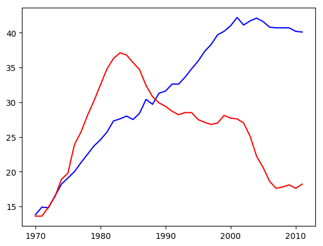

**Example #2: Subplots on Separate Axes**:

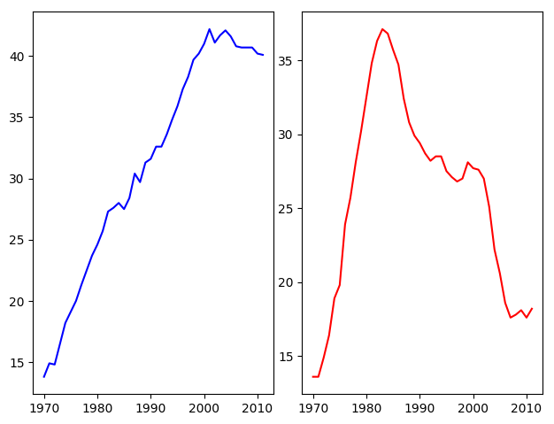

**Example #3: Subplots on Separate Axes with Titles**:

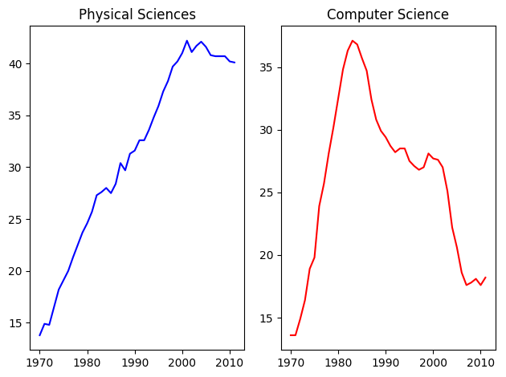

**Example #4: Subplots on Separate Axes with Titles**:

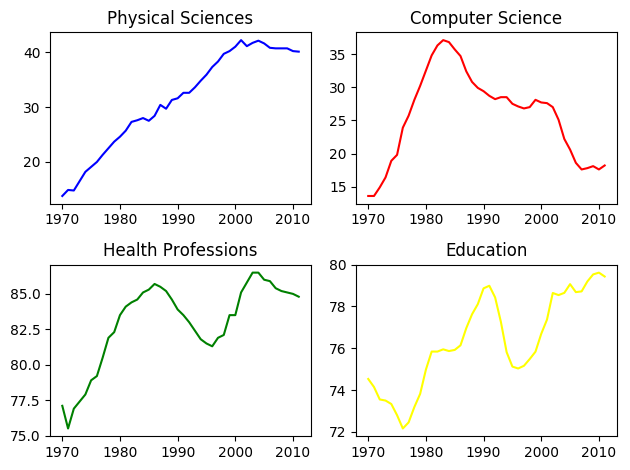

**Example #5: Title and Axis Labels for Two Plots on a Single Set of Axes**:

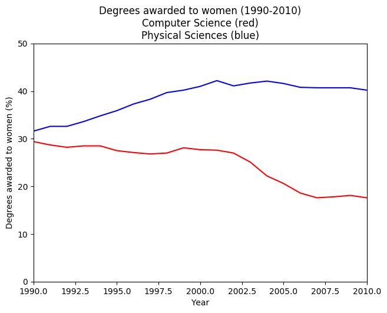

**Example #6: Title, Axis Labels, and Legend for Two Plots on a Single Set of Axes**:

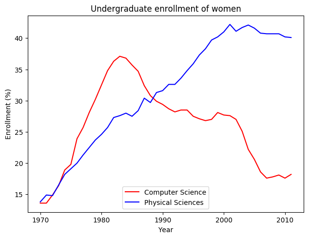

**Example #7: Annotation with Arrow**:

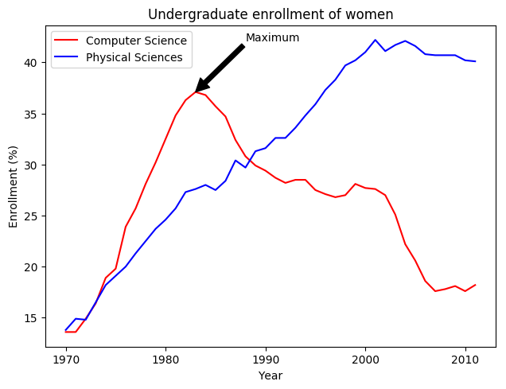

**Example #8: Subplots in ggplot2 Format with One Subplot Annotated**:

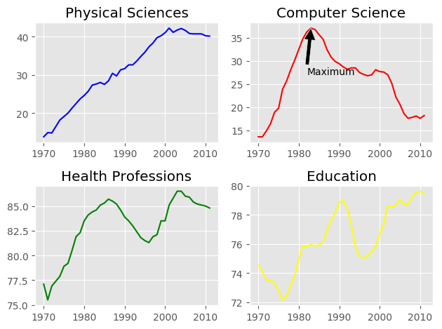

Chapter 2 - Plotting 2D Arrays (Raster Data or Bivariate Function Data)

Working with 2D Arrays - reminders about NumPy arrays:

- NumPy arrays are homogenous in type, allowing for calculations all at once across the entire array
  - A[index] will grab an item from a 1D array
  - A[index0, index1] will grab an item from a 2D array
  - Slicing can be done with start:stop:stride # runs from start to stop-1, with stride being the step
- All images are 2D arrays of intensity - single intensity for gray-scale, multiple intensities (RGB) for color
  - import numpy as np
  - u = np.linspace(-2, 2, 3) # 3 total elements equally spaced from -2 to 2, so [-2, 0, 2]
  - v = np.linspace(-1, 1, 5) # 5 total elements equally spaced from -1 to 1, so [-1, -0.5, 0, 0.5, 1]
  - X, Y = np.meshgrid(u, v) # replicates the 1D grids along different axes, more or less making a 2D array – X and Y are both 5 x 3 with every row of X being u and every column of Y being v
  - Z = X**2/25 + Y**2/4 ; print(“Z:”, Z)
  - plt.set_cmap(“gray”) # sets the color map to grey-scale
  - plt.pcolor(Z) # described later in the chapter, stands for “pseudo-color”
  - plt.show()
- Orientations of 2D arrays and images - arrays are written differently by hand than plotted by computer
  - Plotting runs left-to-right but also bottom-to-top, so the first element of the array (upper-left) will appear in the bottom-left of the image

Visualizing bivariate functions - including the “pseudo-color” (plt.pcolor()) calls:

- Pseudo-color plot are multi-colored and have spill-over (white space on the sides) and have axes that are integers rather than coordinates
  - Can see the colorbar using plt.colorbar() ; this will display the mapping of colors to values in the plot
  - Using the cmap= option within plt.pcolor() allows for over-riding the defaults ; for example, plt.pcolor(Z, cmap=“gray”)
- The issues with spill-over can be addressed using plt.axis(“tight”)
- The issues with the axes as integers can be addressed by calling plt.pcolor(X, Y, Z) where X and Y are the associated elements of the mesh-grid and Z is the value to be plotted
- By design, plt.pcolor() will make “blocky” images, which may be OK depending on the underlying data / issue explored
  - The alternative is to use plt.contour(Z, n), which will make “n” smooth-curves of constant value
  - The other alternative is plt.contourf(Z, n) which will make “n” filled contours of constant value

Visualizing bivariate distributions - distributions of 2D points:

- Example of 2D points given as two 1D arrays x and y (from automobiles data - Weight vs Acceleration), goal is to generate a histogram from x and y
  - For 1D data, the histogram can show the counts of values by bin, accessible using plt.hist()
- For 2D data, there are more options for binning shapes (as opposed to 1D where they will be line segments)
  - Rectangles are the most obvious strategy - plt.hist2d(x, y, bins=(xbins, ybins))
  - Hexagons are another strategy - plt.hexbin(x, y, gridsize=(xSize, ySize)

Working with images (matrices of intensity values):

- Color images are frequently stored as 3-D arrays, one 2-D array for each of Red, Green, Blue
  - The values may range as floats from 0-1 reflecting intensity (0=0%, 1=100%)
  - The values may range as integers from 0-255 reflecting intensity (0=0%, 255=100%)
- Reading and displaying images using matplotlib.pyplot as plt
  - img = plt.imread(“myImageFile”)
  - plt.imshow(img)
  - plt.axis(“off”)
  - plt.show()
- Creating a grey-scale image can be as easy as averaging the intensity across the third dimension (axis=2)
  - collapsed = img.mean(axis=2)
- Default assumption for plotting is that aspect-ratio is 1 (pixel means the same thing in every direction)
  - Can over-ride, such as plt.imshow(img, aspect=2.0)
  - Alternately, can over-ride such as plt.imshow(img, extent=(0, 640, 0, 480)) # value in extent are left, right, bottom, top

Example code includes:

```python
myPath = "./PythonInputFiles/"



# Import numpy and matplotlib.pyplot
import numpy as np
import matplotlib.pyplot as plt

# Generate two 1-D arrays: u, v
u = np.linspace(-2, 2, 41)
v = np.linspace(-1, 1, 21)

# Generate 2-D arrays from u and v: X, Y
X,Y = np.meshgrid(u, v)

# Compute Z based on X and Y
Z = np.sin(3*np.sqrt(X**2 + Y**2))

# Display the resulting image with pcolor()
plt.pcolor(Z)
# plt.show()
plt.savefig("_dummyPy119.png", bbox_inches="tight")
plt.clf()


# Save the figure to 'sine_mesh.png'
# plt.savefig("sine_mesh.png")


u = np.linspace(-2, 2, 101)
v = np.linspace(0, 2, 51)
X,Y = np.meshgrid(u, v)
Z = X**2/8 + Y**2/8


plt.set_cmap("viridis")  # bring back to what it looks like DataCamp may be using

# Generate a default contour map of the array Z
plt.subplot(2,2,1)
plt.contour(X, Y, Z)

# Generate a contour map with 20 contours
plt.subplot(2,2,2)
plt.contour(X, Y, Z, 20)

# Generate a default filled contour map of the array Z
plt.subplot(2,2,3)
plt.contourf(X, Y, Z)

# Generate a default filled contour map with 20 contours
plt.subplot(2,2,4)
plt.contourf(X, Y, Z, 20)

# Improve the spacing between subplots
plt.tight_layout()

# Display the figure
# plt.show()
plt.savefig("_dummyPy120.png", bbox_inches="tight")
plt.clf()


# Create a filled contour plot with a color map of 'viridis'
plt.subplot(2,2,1)
plt.contourf(X,Y,Z,20, cmap='viridis')
plt.colorbar()
plt.title('Viridis')

# Create a filled contour plot with a color map of 'gray'
plt.subplot(2,2,2)
plt.contourf(X,Y,Z,20, cmap='gray')
plt.colorbar()
plt.title('Gray')

# Create a filled contour plot with a color map of 'autumn'
plt.subplot(2,2,3)
plt.contourf(X,Y,Z,20, cmap='autumn')
plt.colorbar()
plt.title('Autumn')

# Create a filled contour plot with a color map of 'winter'
plt.subplot(2,2,4)
plt.contourf(X,Y,Z,20, cmap='winter')
plt.colorbar()
plt.title('Winter')

# Improve the spacing between subplots and display them
plt.tight_layout()
# plt.show()
plt.savefig("_dummyPy121.png", bbox_inches="tight")
plt.clf()


mpg = [18.0, 9.0, 36.100000000000001, 18.5, 34.299999999999997, 32.899999999999999, 32.200000000000003, 22.0, 15.0, 17.0, 44.0, 24.5, 32.0, 14.0, 15.0, 13.0, 36.0, 31.0, 32.0, 21.5, 19.0, 17.0, 16.0, 15.0, 23.0, 26.0, 32.0, 24.0, 21.0, 31.300000000000001, 32.700000000000003, 15.0, 23.0, 17.600000000000001, 28.0, 24.0, 14.0, 18.100000000000001, 36.0, 29.0, 35.100000000000001, 36.0, 16.5, 16.0, 29.899999999999999, 31.0, 27.199999999999999, 14.0, 32.100000000000001, 15.0, 12.0, 17.600000000000001, 25.0, 28.399999999999999, 29.0, 30.899999999999999, 20.0, 20.800000000000001, 22.0, 38.0, 31.0, 19.0, 16.0, 25.0, 22.0, 26.0, 13.0, 19.899999999999999, 11.0, 28.0, 15.5, 26.0, 14.0, 12.0, 24.199999999999999, 25.0, 22.5, 26.800000000000001, 23.0, 26.0, 30.699999999999999, 31.0, 27.199999999999999, 21.5, 29.0, 20.0, 13.0, 14.0, 38.0, 13.0, 24.5, 13.0, 25.0, 24.0, 34.100000000000001, 13.0, 44.600000000000001, 20.5, 18.0, 23.199999999999999, 20.0, 24.0, 25.5, 36.100000000000001, 23.0, 24.0, 18.0, 26.600000000000001, 32.0, 20.300000000000001, 27.0, 17.0, 21.0, 13.0, 24.0, 17.0, 39.100000000000001, 14.5, 13.0, 20.199999999999999, 27.0, 35.0, 15.0, 36.399999999999999, 30.0, 31.899999999999999, 26.0, 16.0, 20.0, 18.600000000000001, 14.0, 25.0, 33.0, 14.0, 18.5, 37.200000000000003, 18.0, 44.299999999999997, 18.0, 28.0, 43.399999999999999, 20.600000000000001, 19.199999999999999, 26.399999999999999, 18.0, 28.0, 26.0, 13.0, 25.800000000000001, 28.100000000000001, 13.0, 16.5, 31.5, 24.0, 15.0, 18.0, 33.5, 32.399999999999999, 27.0, 13.0, 31.0, 28.0, 27.199999999999999, 21.0, 19.0, 25.0, 23.0, 19.0, 15.5, 23.899999999999999, 22.0, 29.0, 14.0, 15.0, 27.0, 15.0, 30.5, 25.0, 17.5, 34.0, 38.0, 30.0, 19.800000000000001, 25.0, 21.0, 26.0, 16.5, 18.100000000000001, 46.600000000000001, 21.5, 14.0, 21.600000000000001, 15.5, 20.5, 23.899999999999999, 12.0, 20.199999999999999, 34.399999999999999, 23.0, 24.300000000000001, 19.0, 29.0, 23.5, 34.0, 37.0, 33.0, 18.0, 15.0, 34.700000000000003, 19.399999999999999, 32.0, 34.100000000000001, 33.700000000000003, 20.0, 15.0, 38.100000000000001, 26.0, 27.0, 16.0, 17.0, 13.0, 28.0, 14.0, 31.5, 34.5, 11.0, 16.0, 31.600000000000001, 19.100000000000001, 18.5, 15.0, 18.0, 35.0, 20.199999999999999, 13.0, 31.0, 22.0, 11.0, 33.5, 43.100000000000001, 25.399999999999999, 40.799999999999997, 14.0, 29.800000000000001, 16.0, 20.600000000000001, 18.0, 33.0, 31.800000000000001, 13.0, 20.0, 32.0, 13.0, 23.699999999999999, 19.199999999999999, 37.0, 18.0, 19.0, 32.299999999999997, 18.0, 13.0, 12.0, 36.0, 18.199999999999999, 19.0, 30.0, 15.0, 11.0, 10.0, 16.0, 14.0, 16.899999999999999, 13.0, 25.0, 21.0, 21.100000000000001, 26.0, 28.0, 29.0, 16.0, 26.600000000000001, 19.0, 32.799999999999997, 22.0, 19.0, 31.0, 23.0, 29.5, 17.5, 19.0, 24.0, 14.0, 28.0, 21.0, 22.399999999999999, 36.0, 18.0, 16.199999999999999, 39.399999999999999, 30.0, 18.0, 17.5, 28.800000000000001, 22.0, 34.200000000000003, 30.5, 16.0, 38.0, 41.5, 27.899999999999999, 22.0, 29.800000000000001, 17.699999999999999, 15.0, 14.0, 15.5, 17.5, 12.0, 29.0, 15.5, 35.700000000000003, 26.0, 30.0, 33.799999999999997, 18.0, 13.0, 20.0, 32.399999999999999, 16.0, 27.5, 23.0, 14.0, 17.0, 16.0, 23.0, 24.0, 27.0, 15.0, 27.0, 28.0, 14.0, 33.5, 39.0, 24.0, 26.5, 19.399999999999999, 15.0, 25.5, 14.0, 27.399999999999999, 13.0, 19.0, 17.0, 28.0, 22.0, 30.0, 18.0, 14.0, 22.0, 23.800000000000001, 24.0, 26.0, 26.0, 30.0, 29.0, 14.0, 25.399999999999999, 19.0, 12.0, 20.0, 27.0, 22.300000000000001, 10.0, 19.199999999999999, 26.0, 16.0, 37.299999999999997, 26.0, 20.199999999999999, 13.0, 21.0, 25.0, 20.5, 37.700000000000003, 36.0, 20.0, 37.0, 18.0, 27.0, 29.5, 17.5, 25.100000000000001]
hp = [88, 193, 60, 98, 78, 100, 75, 76, 130, 140, 52, 88, 84, 148, 150, 130, 58, 82, 65, 110, 95, 110, 140, 170, 78, 90, 96, 95, 110, 75, 132, 150, 83, 85, 86, 75, 140, 139, 70, 52, 60, 84, 138, 180, 65, 67, 97, 150, 70, 100, 180, 129, 95, 90, 83, 75, 100, 85, 112, 67, 65, 88, 100, 75, 100, 70, 145, 110, 210, 80, 145, 69, 150, 198, 120, 92, 90, 115, 95, 75, 76, 67, 71, 115, 84, 91, 150, 215, 67, 175, 60, 175, 110, 95, 68, 150, 67, 95, 110, 105, 102, 110, 89, 66, 88, 75, 78, 105, 70, 103, 60, 150, 72, 170, 90, 110, 58, 152, 145, 139, 83, 69, 150, 67, 80, 71, 46, 105, 90, 110, 175, 80, 74, 150, 150, 65, 100, 48, 105, 90, 48, 105, 105, 88, 100, 75, 113, 190, 92, 80, 165, 180, 71, 97, 72, 105, 90, 75, 88, 155, 68, 90, 84, 87, 112, 87, 125, 108, 142, 97, 105, 75, 137, 150, 88, 145, 63, 95, 140, 88, 85, 70, 85, 115, 86, 79, 120, 120, 65, 110, 220, 115, 170, 100, 90, 225, 85, 65, 97, 90, 90, 49, 110, 70, 92, 53, 100, 190, 63, 90, 67, 65, 75, 100, 110, 60, 93, 88, 150, 100, 150, 88, 225, 68, 70, 208, 105, 74, 90, 110, 72, 97, 88, 88, 129, 85, 86, 150, 70, 48, 77, 65, 175, 90, 150, 110, 130, 53, 65, 158, 95, 61, 215, 100, 145, 68, 150, 88, 67, 105, 175, 160, 74, 135, 100, 67, 198, 180, 215, 100, 225, 155, 170, 81, 85, 95, 80, 92, 70, 149, 84, 97, 52, 72, 85, 52, 95, 71, 140, 100, 96, 150, 75, 107, 110, 75, 97, 133, 70, 67, 112, 145, 115, 98, 70, 78, 230, 63, 76, 105, 95, 62, 165, 165, 160, 190, 95, 180, 78, 120, 80, 75, 68, 67, 95, 140, 110, 72, 150, 95, 54, 153, 130, 170, 86, 97, 90, 145, 86, 79, 165, 83, 64, 92, 72, 140, 150, 96, 150, 80, 130, 100, 125, 90, 94, 76, 90, 150, 97, 85, 81, 78, 46, 84, 70, 153, 116, 100, 167, 88, 88, 88, 200, 125, 92, 110, 69, 67, 90, 150, 90, 71, 105, 62, 88, 122, 65, 88, 90, 68, 110, 88]

# Generate a 2-D histogram
plt.hist2d(hp, mpg, bins=(20, 20), range=((40, 235), (8, 48)))

# Add a color bar to the histogram
plt.colorbar()

# Add labels, title, and display the plot
plt.xlabel('Horse power [hp]')
plt.ylabel('Miles per gallon [mpg]')
plt.title('hist2d() plot')
# plt.show()
plt.savefig("_dummyPy122.png", bbox_inches="tight")
plt.clf()


# Generate a 2d histogram with hexagonal bins
plt.hexbin(hp, mpg, gridsize=(15, 12), extent=(40, 235, 8, 48))

# Add a color bar to the histogram
plt.colorbar()

# Add labels, title, and display the plot
plt.xlabel('Horse power [hp]')
plt.ylabel('Miles per gallon [mpg]')
plt.title('hexbin() plot')
# plt.show()
plt.savefig("_dummyPy123.png", bbox_inches="tight")
plt.clf()


# Load the image into an array: img
# Downloaded Astrounaut-EVA.jpg from https://en.wikipedia.org/wiki/File:Astronaut-EVA.jpg
# img = plt.imread('480px-Astronaut-EVA.jpg')
# Cannot be read on my computer using regular Python but OK with Anaconda . . .
img = plt.imread(myPath + 'Astronaut-EVA.jpg')


# Print the shape of the image
print(img.shape)

# Display the image
plt.imshow(img)

# Hide the axes
plt.axis("off")
# plt.show()
plt.savefig("_dummyPy124.png", bbox_inches="tight")
plt.clf()



# Compute the sum of the red, green and blue channels: intensity
intensity = img.sum(axis=2)

# Print the shape of the intensity
print(intensity.shape)

# Display the intensity with a colormap of 'gray'
plt.imshow(intensity, cmap="gray")

# Add a colorbar
plt.colorbar()

# Hide the axes and show the figure
plt.axis('off')
# plt.show()
plt.savefig("_dummyPy125.png", bbox_inches="tight")
plt.clf()


# Specify the extent and aspect ratio of the top left subplot
plt.subplot(2,2,1)
plt.title('extent=(-1,1,-1,1),\naspect=0.5')
plt.xticks([-1,0,1])
plt.yticks([-1,0,1])
plt.imshow(img, extent=(-1,1,-1,1), aspect=0.5)

# Specify the extent and aspect ratio of the top right subplot
plt.subplot(2,2,2)
plt.title('extent=(-1,1,-1,1),\naspect=1')
plt.xticks([-1,0,1])
plt.yticks([-1,0,1])
plt.imshow(img, extent=(-1,1,-1,1), aspect=1)

# Specify the extent and aspect ratio of the bottom left subplot
plt.subplot(2,2,3)
plt.title('extent=(-1,1,-1,1),\naspect=2')
plt.xticks([-1,0,1])
plt.yticks([-1,0,1])
plt.imshow(img, extent=(-1,1,-1,1), aspect=2)

# Specify the extent and aspect ratio of the bottom right subplot
plt.subplot(2,2,4)
plt.title('extent=(-2,2,-1,1),\naspect=2')
plt.xticks([-2,-1,0,1,2])
plt.yticks([-1,0,1])
plt.imshow(img, extent=(-2,2,-1,1), aspect=2)

# Improve spacing and display the figure
plt.tight_layout()
# plt.show()
plt.savefig("_dummyPy126.png", bbox_inches="tight")
plt.clf()


# Downloaded Unequalized_Hawkes_Bay_NZ.jpg from https://commons.wikimedia.org/wiki/File:Unequalized_Hawkes_Bay_NZ.jpg
# Load the image into an array: image
# image = plt.imread('640px-Unequalized_Hawkes_Bay_NZ.jpg')
image = plt.imread(myPath + 'Unequalized_Hawkes_Bay_NZ.jpg')

# Extract minimum and maximum values from the image: pmin, pmax
pmin, pmax = image.min(), image.max()
print("The smallest & largest pixel intensities are %d & %d." % (pmin, pmax))

# Rescale the pixels: rescaled_image
imageMean = image.mean(axis=2)
rescaled_image = 256*(imageMean - pmin) / (pmax - pmin)
print("The rescaled smallest & largest pixel intensities are %.1f & %.1f." %
      (rescaled_image.min(), rescaled_image.max()))

# Make it a 3D Numpy array for grayscale
# rescaled_gray = np.zeros((imageMean.shape[0], imageMean.shape[1], 3))

# rescaled_gray[:, :, 0] = rescaled_image
# rescaled_gray[:, :, 1] = rescaled_image
# rescaled_gray[:, :, 2] = rescaled_image

# Display the original image in the top subplot
plt.subplot(2,1,1)
plt.title('original image')
plt.axis('off')
plt.imshow(image)

# Display the rescaled image in the bottom subplot
plt.subplot(2,1,2)
plt.title('rescaled image')
plt.axis('off')
plt.imshow(rescaled_image, cmap="gray")

# plt.show()
plt.savefig("_dummyPy127.png", bbox_inches="tight")
plt.clf()
```

```
## (3072, 3072, 3)
## (3072, 3072)
## The smallest & largest pixel intensities are 114 & 208.
## The rescaled smallest & largest pixel intensities are 0.0 & 256.0.
```

**Example #1: Pseudo-Color Plot**:

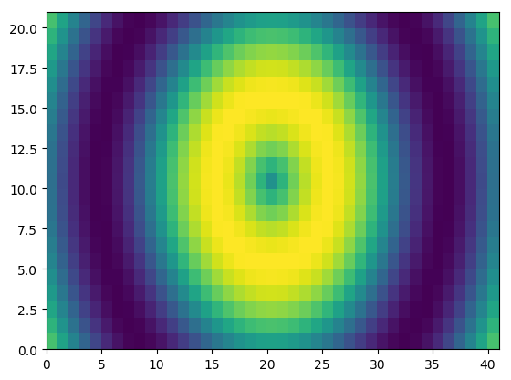

**Example #2: Pseudo-Color Contour Plot**:

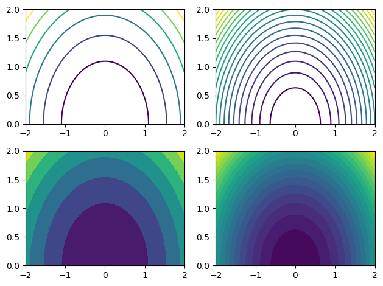

**Example #3: Varying the Color Map**:

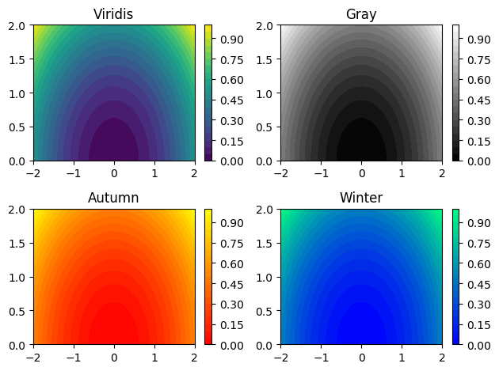

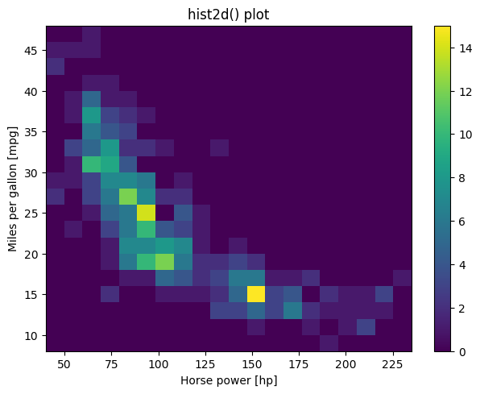

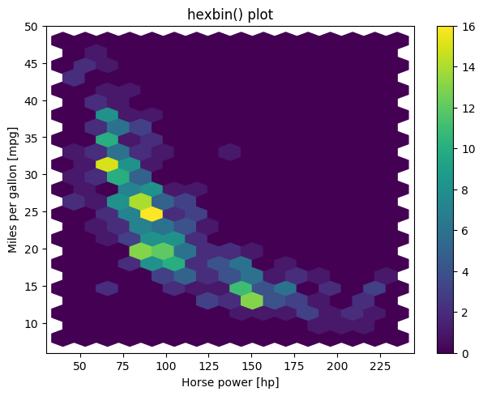

**Example #6: Astronaut Image**:

[figure not shown]

**Example #7: Astronaut Image (GrayScale)**:

[figure not shown]

**Example #8: Astronaut Image (Aspect Ratio)**:

[figure not shown]

**Example #9: Hawkes Bay Image (Raw and Rescaled)**:

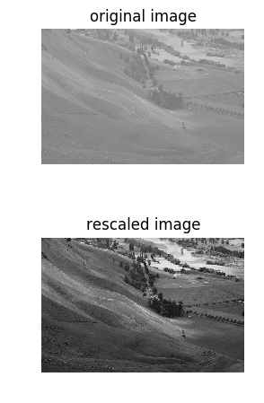

Chapter 3 - Statistical Plots with Seaborn (statistical data visualization package)

General background - designed by Michael Waskom (Stanford):

- High-level interface for drawing attractive statistical graphics
- Drawn on top of matplotlib - makes plotting both easier and prettier
- Works best with pandas DataFrames rather than NumPy arrays or lists or anything else

Visualizing Regressions - using the “tips” data and looking at “tip” vs. “total_bill”:

- Basic data process for plotting a regression using Seaborn
  - import pandas as pd
  - import matplotlib.pyplot as plt
  - import seaborn as sns
  - tips = sns.load_dataset(“tips”) # Seaborn data-loading function
  - sns.lmplot(x = “total_bill”, y = “tip”, data=tips) # runs the regression, plots both the underlying data and the regression line
  - plt.show()
- Grouping factor variables, but displaying them on the same plot
  - sns.lmplot(x = “total_bill”, y = “tip”, data=tips, hue=“sex”, palette=“Set1”) # runs the regression, plots both the underlying data and the regression line, colors everything by “sex” (factor variable) using “Set1” palette
- Grouping factor variables, and displaying them as separate sub-plots
  - sns.lmplot(x = “total_bill”, y = “tip”, data=tips, col=“sex”) # runs the regression, plots both the underlying data and the regression line, colors everything by “sex” (factor variable) using “Set1” palette
  - The sns.lmplot() accepts the arguments row and/or col to arrangements of subplots for regressions
- Residual plots can be obtained using residplot
  - sns.residplot(x=“age”, y=“fare”, data=tips, color=“indianred”)
  - The residplot is somewhat more flexible, in that x/y could be lists or NumPy arrays with data skipped as an input

Visualizing univariate distributions - strip plots, swarm plots, violin plots:

- Strip plots - variables drawn on a single line (optionally, by category)
  - sns.stripplot(y = “tip”, data=tips) # single strip-plot of all the data
  - sns.stripplot(x=“day”, y = “tip”, data=tips) # strip-plot of all data, once for each value of “day”
  - Repeated values are drawn on top of each other by default, so there is no way to say where the most frequenct values have occurred
  - Can add “jitter” to the plot, using sns.stripplot(x=“day”, y = “tip”, data=tips, size=4, jitter=True)
- Swarm plots - somewhat like strip plots, but automatically represent repeated data as multiple points
  - sns.swarmplot(x=“day”, y = “tip”, data=tips) # swarm-plot of all data, once for each value of “day”
  - sns.swarmplot(x=“day”, y = “tip”, data=tips, hue=“sex”) # swarm-plot of all the data, once for each value of “day”, and with points colored by “sex” (factor variable)
  - Can change orientation by swapping x/y arguments and adding orient=“h” - so, sns.swarmplot(y=“day”, x = “tip”, data=tips, hue=“sex”, orient=“h”)
- Violin plots (fancier form of box plots) are more useful then strip/swarm plots in the presence of a very large volume of data
  - Based on the KDE - kernel density estimate - wrapped around a box plot, leading to a thicker violin where there is more data
  - sns.violinplot(x=“day”, y = “tip”, data=tips) # violin-plot of all the data, once for each value of “day”
- Can combine multiple plot-types on the same graph, including
  - sns.violinplot(x=“day”, y = “tip”, data=tips, inner=None, color=“lightgray”) # violin-plot of all the data, once for each value of “day”, and with no colored fills of the violin
  - sns.stripplot(x=“day”, y = “tip”, data=tips, size=4, jitter=True) # overlays the strip-plot on the violin-plot
  - plt.show() # shows the full dataset

Visualizing bivariate / multivariate distributions - joint plots, pair plots, heat maps:

- Joint plot - show the scatter plot of two variables, with the univariate histograms of each variable showed above (for x) and to the right (y) of the scatter
  - sns.jointplot(x=“total_bill”, y=“tip”, data=tips)
  - sns.jointplot(x=“total_bill”, y=“tip”, data=tips, kind=“kde”) # will produce smooth graphs using the Kernel Density Estimate for the scatter (contours) and histograms
  - kind=‘scatter’ uses a scatter plot of the data points
  - kind=‘reg’ uses a regression plot (default order 1)
  - kind=‘resid’ uses a residual plot
  - kind=‘kde’ uses a kernel density estimate of the joint distribution
  - kind=‘hex’ uses a hexbin plot of the joint distribution
- Pair plot - scatter plot of every possible pair of variables, with diagonals being self-histograms and off-diagonals being repeated (though as a transpose)
  - sns.pairplot(tips) # categorical variables will NOT be plotted ; only continuous, numeric variables
  - sns.pairplot(tips, hue=“sex”) # points will be colored by “sex” (categorical variables)
- Heat map - covariance matrix represented as pseudo-colors, and with some additional functionality
  - Assume that a covariance matrix has already been created, conveniently called “covariance”
  - sns.heatmap(covariance)
  - Typically used for gene expression, stocks, and other areas where there are a vast number of comparisons to be run

Example code includes:

```python
myPath = "./PythonInputFiles/"



# NEED TO BRING OVER "auto" data
import pandas as pd

auto = pd.read_csv(myPath + "mtcars.csv", index_col=0)
auto = auto[["mpg", "wt", "hp", "cyl", "am", "disp"]]

# Import plotting modules
import matplotlib.pyplot as plt
import seaborn as sns

# Plot a linear regression between 'weight' and 'hp'
sns.lmplot(x='wt', y='hp', data=auto)

# Display the plot
# plt.show()
plt.savefig("_dummyPy128.png", bbox_inches="tight")
plt.clf()


# Generate a green residual plot of the regression between 'hp' and 'mpg'
sns.residplot(x='hp', y='mpg', data=auto, color='green')

# Display the plot
# plt.show()
plt.savefig("_dummyPy129.png", bbox_inches="tight")
plt.clf()


# Generate a scatter plot of 'weight' and 'mpg' using red circles
plt.scatter(auto['wt'], auto["mpg"], label='data', color='red', marker='o')

# Plot in blue a linear regression of order 1 between 'weight' and 'mpg'
sns.regplot(x='wt', y='mpg', data=auto, color="blue", scatter=None, label='order 1')

# Plot in green a linear regression of order 2 between 'weight' and 'mpg'
sns.regplot(x='wt', y='mpg', data=auto, color="green", scatter=None, order=2, label='order 2')

# Add a legend and display the plot
plt.legend(loc="upper right")
# plt.show()
plt.savefig("_dummyPy130.png", bbox_inches="tight")
plt.clf()


# Plot a linear regression between 'weight' and 'hp', with a hue of 'cyl' and palette of 'Set1'
sns.lmplot(x="wt", y="hp", data=auto, hue="cyl", palette="Set1")

# Display the plot
# plt.show()
plt.savefig("_dummyPy131.png", bbox_inches="tight")
plt.clf()


# Plot linear regressions between 'weight' and 'hp' grouped row-wise by 'cyl'
sns.lmplot(x = "wt", y="hp", data=auto, row="cyl")

# Display the plot
# plt.show()
plt.savefig("_dummyPy132.png", bbox_inches="tight")
plt.clf()


# Make a strip plot of 'hp' grouped by 'cyl'
plt.subplot(2,1,1)
sns.stripplot(x="cyl", y="hp", data=auto)

# Make the strip plot again using jitter and a smaller point size
plt.subplot(2,1,2)
sns.stripplot(x="cyl", y="hp", data=auto, size=3, jitter=True)

# Display the plot
# plt.show()
plt.savefig("_dummyPy133.png", bbox_inches="tight")
plt.clf()


# Generate a swarm plot of 'hp' grouped horizontally by 'cyl'
plt.subplot(2,1,1)
sns.swarmplot(x="cyl", y="hp", data=auto)

# Generate a swarm plot of 'hp' grouped vertically by 'cyl' with a hue of 'am'
plt.subplot(2,1,2)
sns.swarmplot(y="cyl", x="hp", data=auto, hue="am", orient="h")

# Display the plot
# plt.show()
plt.savefig("_dummyPy134.png", bbox_inches="tight")
plt.clf()


# Generate a violin plot of 'hp' grouped horizontally by 'cyl'
plt.subplot(2,1,1)
sns.violinplot(x="cyl", y="hp", data=auto)

# Generate the same violin plot again with a color of 'lightgray' and without inner annotations
plt.subplot(2,1,2)
sns.violinplot(x="cyl", y="hp", data=auto, color="lightgray", inner=None)

# Overlay a strip plot on the violin plot
sns.stripplot(x="cyl", y="hp", data=auto, size=1.5, jitter=True)

# Display the plot
# plt.show()
plt.savefig("_dummyPy135.png", bbox_inches="tight")
plt.clf()


# Generate a joint plot of 'hp' and 'mpg'
sns.jointplot(x="hp", y="mpg", data=auto)

# Display the plot
# plt.show()
plt.savefig("_dummyPy136.png", bbox_inches="tight")
plt.clf()


# Generate a joint plot of 'hp' and 'mpg' using a hexbin plot
sns.jointplot(x="hp", y="mpg", data=auto, kind="hex")

# Display the plot
# plt.show()
plt.savefig("_dummyPy137.png", bbox_inches="tight")
plt.clf()


# Print the first 5 rows of the DataFrame
print(auto.head())

# Plot the pairwise joint distributions from the DataFrame
sns.pairplot(auto)

# Display the plot
# plt.show()
plt.savefig("_dummyPy138.png", bbox_inches="tight")
plt.clf()


# Plot the pairwise joint distributions grouped by 'am' along with regression lines
sns.pairplot(auto, hue="am", kind="reg")

# Display the plot
# plt.show()
plt.savefig("_dummyPy139.png", bbox_inches="tight")
plt.clf()


# NEED DATA - cov_matrix is 5x5 with mpg-hp-weight-accel-displ
# Print the covariance matrix
# print(cov_matrix)

# Visualize the covariance matrix using a heatmap
# sns.heatmap(cov_matrix)

# Display the heatmap
# plt.show()
```

```
##                     mpg     wt   hp  cyl  am   disp
## Mazda RX4          21.0  2.620  110    6   1  160.0
## Mazda RX4 Wag      21.0  2.875  110    6   1  160.0
## Datsun 710         22.8  2.320   93    4   1  108.0
## Hornet 4 Drive     21.4  3.215  110    6   0  258.0
## Hornet Sportabout  18.7  3.440  175    8   0  360.0
```

**Example #1: Seaborn Linear Regression Plot (sns.lmplot)**:

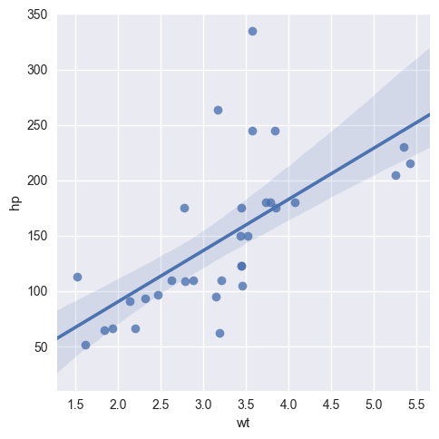

**Example #2: Seaborn Residual Plot (sns.residplot)**:

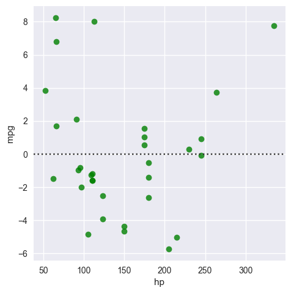

**Example #3: Labelled Plots (Raw Data, Order 1 Regression, Order 2 Regression)**:

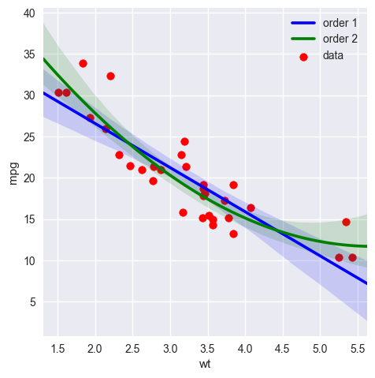

**Example #4: Regressions Stratified by Factor Using Colors**:

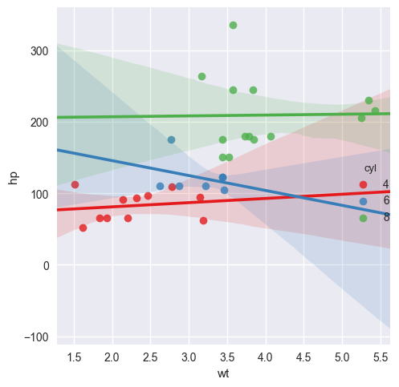

**Example #5: Regression Stratified by Factor (Separate Plots)**:

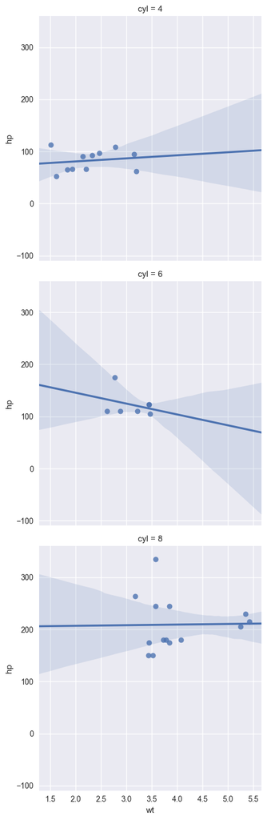

**Example #6: Strip Plot**:

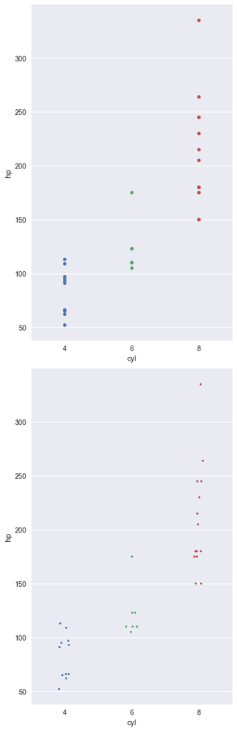

**Example #7: Swarm Plot**:

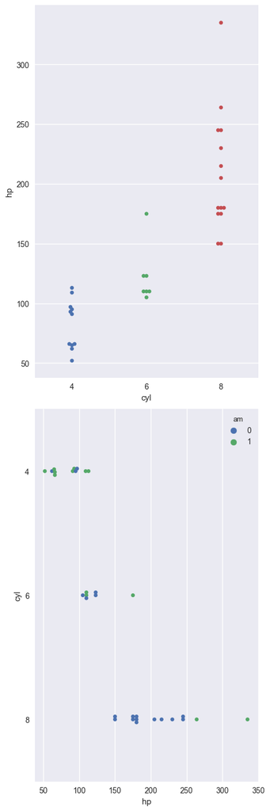

**Example #8: Violin Plot**:

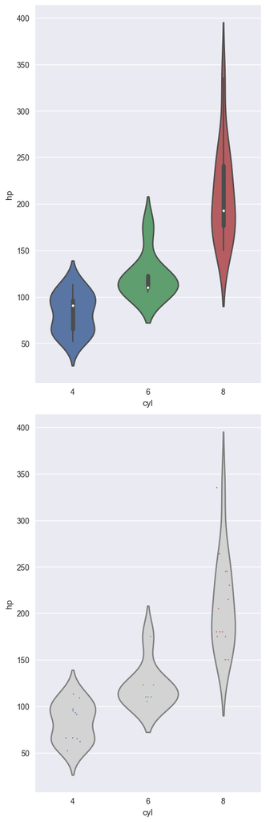

**Example #9: Joint Plot (sns.jointplot)**:

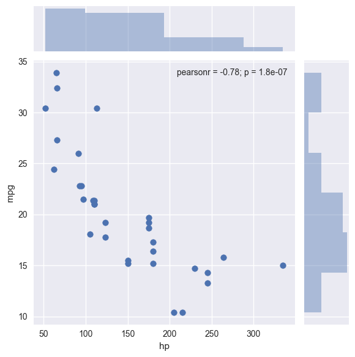

**Example #10: Joint Plot (Hexagonal)**:

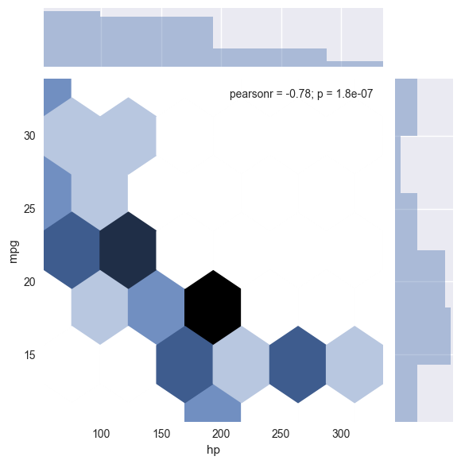

**Example #11: Pair Plot (sns.pairplot)**:

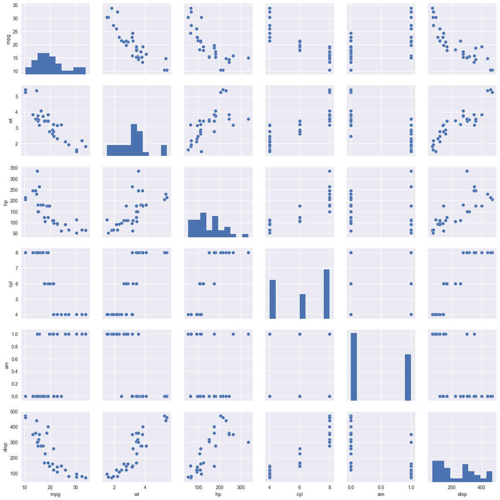

**Example #12: Pair Plot Stratified Using Color (sns.pairplot)**:

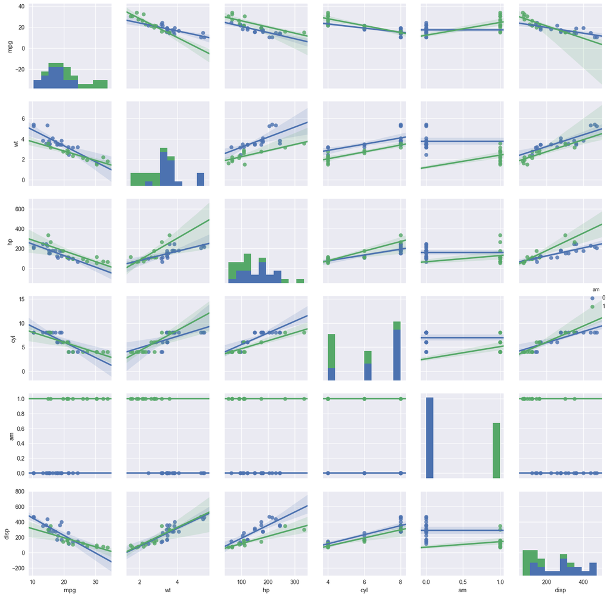

Chapter 4 - Analyzing time series

Visualizing time series - example of the Austin 2010 weather data:

- Time series have a “datetime” as their index, representing various time periods or time stamps
- Time series are particularly valuable in pandas due to slicing - weather[“2010-07-04”] will slice ALL rows from July 4, 2010 in “weather”
- If the index has hourly data, could set dates = dates = weather.index[::96] to select every 96th record (which will be every fourth day)
  - Can then format these dates using strftime - labels = dates.strftime(“%b %d”)
  - plt.xticks(dates, labels, rotation=60) # will place labels (formatted dates) at each of dates (every 4 days), rotated at 60 degrees

Time series with moving windows - taking a sample statistic (such as average or max/min) over a longer time period:

- Suppose that the temperature data is still hourly, and that resampled averages have been used to create DataFrame smoothed with columns [‘1d’, ‘3d’, ‘7d’, ‘14d’]
  - plt.plot(smoothed[“2010-01”])
  - plt.legend(smoothed.columns)
  - plt.title(“Temperature (Jan. 2010)”)
  - plt.xticks(rotation=60)
  - plt.show()

Histogram equilization in images - spreading out intensities so that subtle contrasts can be enhanced:

- Investigating a histogram of pixel intensities can suggest whether the intensities may be insufficiently spread out
  - The .flatten() method applied to a NumPy array will convert 2D data to 1D data
  - The .reshape(myDF.shape) method applied to 1D data will re-shape the data to whatever is in myDF.shape
- A basic rescaling of intensities is to run (X - X.min()) / (X.max() - X.min())
  - The image may not look materially different, though
- Can investigate the CDF as well as the PDF for the original image data
  - plt.hist(pixels, bins=256, range=(0, 256), normed=True, color=“blue”, alpha=0.3)
  - plt.twinx() # set up the second y-axis, with graphs overlaid
  - orig_cdf, bins, patches = plt.hist(pixels, cumulative=True, bins=256, range=(0, 256), normed=True, color=“red”, alpha=0.3)
  - plt.title(“Image histogram and CDF”)
  - plt.xlim(0, 255)
  - plt.show()
- Can use interpolation to equalize the intensity values - resulting CDF looks more like a ramp from 0-255 rather than being “spiky” around a small area
  - new_pixels = np.interp(pixels, bins[:-1], orig_cdf * 255)
  - plt.imshow(new_pixels.reshape(orig.shape))
  - plt.axis(“off”)
  - plt.title(“Equalized image”)
  - plt.show()

Example code includes:

```python
myPath = "./PythonInputFiles/"



# Load the relevant stocks data
import pandas as pd
import numpy as np
from datetime import datetime

rawStocks = pd.read_csv(myPath + "StockChart_20170615.csv", header=None, index_col=None)
rawStocks["Date"] = [datetime.strptime(x.split()[0], "%m/%d/%Y") for x in rawStocks.iloc[:, 1]]
rawStocks["Price"] = [float(x.split()[1]) for x in rawStocks.iloc[:, 1]]


aapl = rawStocks.loc[rawStocks.iloc[:, 0] == "AAPL", ["Date", "Price"]].set_index("Date").sort_index()
goog = rawStocks.loc[rawStocks.iloc[:, 0] == "GOOG", ["Date", "Price"]].set_index("Date").sort_index()
ibm = rawStocks.loc[rawStocks.iloc[:, 0] == "IBM", ["Date", "Price"]].set_index("Date").sort_index()


# Import matplotlib.pyplot
import matplotlib.pyplot as plt

# Plot the aapl time series in blue
plt.plot(aapl, color="blue", label='AAPL')

# Plot the ibm time series in green
plt.plot(ibm, color='green', label='IBM')

# Plot the goog time series in red
plt.plot(goog, color='red', label='GOOG')

# Add a legend in the top left corner of the plot
plt.legend(loc='upper left')

# Specify the orientation of the xticks
plt.xticks(rotation=60)

# Display the plot
# plt.show()
plt.savefig("_dummyPy140.png", bbox_inches="tight")
plt.clf()

# Plot the series in the top subplot in blue
plt.subplot(2,1,1)
plt.xticks(rotation=45)
plt.title('AAPL: MAT June 2017')
plt.plot(aapl, color='blue')

# Slice aapl from '2017-01' to '2017-02' inclusive: view
view = aapl['2017-01':'2017-02']

# Plot the sliced data in the bottom subplot in black
plt.subplot(2,1,2)
plt.xticks(rotation=45)
plt.title('AAPL: 2017-01 to 2017-02')
plt.plot(view, color="black")

plt.tight_layout()
# plt.show()
plt.savefig("_dummyPy141.png", bbox_inches="tight")
plt.clf()


# Slice aapl from Nov. 2016 to Apr. 2017 inclusive: view
view = aapl['2016-11':'2017-04']

# Plot the sliced series in the top subplot in red
plt.subplot(2, 1, 1)
plt.plot(view, color="red")
plt.title('AAPL: Nov. 2016 to Apr. 2017')
plt.xticks(rotation=45)

# Reassign the series by slicing the month January 2017
view = aapl['2017-01']

# Plot the sliced series in the bottom subplot in green
plt.subplot(2, 1, 2)
plt.plot(view, color="green")
plt.title('AAPL: Jan. 2017')
plt.xticks(rotation=45)

# Improve spacing and display the plot
plt.tight_layout()
# plt.show()
plt.savefig("_dummyPy142.png", bbox_inches="tight")
plt.clf()

# Slice aapl from Nov. 2016 to Apr. 2017 inclusive: view
view = aapl['2016-11':'2017-04']

# Plot the entire series
plt.plot(aapl)
plt.xticks(rotation=45)
plt.title('AAPL: MAT June 2017')

# Specify the axes
plt.axes([0.25, 0.5, 0.35, 0.35])

# Plot the sliced series in red using the current axes
plt.plot(view, color="red")
plt.xticks(rotation=45)
plt.title('2016/11-2017/04')

# plt.show()
plt.savefig("_dummyPy143.png", bbox_inches="tight")
plt.clf()


# BASED OFF THE aapl DATASET
mean_10 = aapl.rolling(window=10).mean()
mean_30 = aapl.rolling(window=30).mean()
mean_75 = aapl.rolling(window=75).mean()
mean_125 = aapl.rolling(window=125).mean()

# Plot the 10-day moving average in the top left subplot in green
plt.subplot(2, 2, 1)
plt.plot(mean_10, color="green")
plt.plot(aapl, 'k-.')
plt.xticks(rotation=60)
plt.title('10d averages')

# Plot the 30-day moving average in the top right subplot in red
plt.subplot(2, 2, 2)
plt.plot(mean_30, 'red')
plt.plot(aapl, 'k-.')
plt.xticks(rotation=60)
plt.title('30d averages')

# Plot the 75-day moving average in the bottom left subplot in magenta
plt.subplot(2, 2, 3)
plt.plot(mean_75, color="magenta")
plt.plot(aapl, 'k-.')
plt.xticks(rotation=60)
plt.title('75d averages')

# Plot the 125-day moving average in the bottom right subplot in cyan
plt.subplot(2, 2, 4)
plt.plot(mean_125, color="cyan")
plt.plot(aapl, 'k-.')
plt.xticks(rotation=60)
plt.title('125d averages')

# Display the plot
# plt.show()
plt.savefig("_dummyPy144.png", bbox_inches="tight")
plt.clf()



std_10 = aapl.rolling(window=10).std()
std_30 = aapl.rolling(window=30).std()
std_75 = aapl.rolling(window=75).std()
std_125 = aapl.rolling(window=125).std()

# Plot std_10 in red
plt.plot(std_10, color="red", label='10d')

# Plot std_30 in cyan
plt.plot(std_30, color="cyan", label='30d')

# Plot std_75 in green
plt.plot(std_75, color="green", label='75d')

# Plot std_125 in magenta
plt.plot(std_125, color="magenta", label='125d')

# Add a legend to the upper left
plt.legend(loc="upper left")

# Add a title
plt.title('Moving standard deviations')

# Display the plot
# plt.show()
plt.savefig("_dummyPy145.png", bbox_inches="tight")
plt.clf()


# IMAGE AVAILABLE AT https://commons.wikimedia.org/wiki/File:Unequalized_Hawkes_Bay_NZ.jpg
# Load the image into an array, keeping just one of the RGB layers: image
image = plt.imread(myPath + 'Unequalized_Hawkes_Bay_NZ.jpg')[:, :, 0]

# Display image in top subplot using color map 'gray'
plt.subplot(2,1,1)
plt.title('Original image')
plt.axis('off')
plt.imshow(image, cmap="gray")

# Flatten the image into 1 dimension: pixels
pixels = image.flatten()

# Display a histogram of the pixels in the bottom subplot
plt.subplot(2,1,2)
plt.xlim((0,255))
plt.title('Normalized histogram')
plt.hist(pixels, bins=64, range=(0, 256), normed=True, color="red", alpha=0.4)

# Display the plot
# plt.show()
plt.savefig("_dummyPy146.png", bbox_inches="tight")
plt.clf()


# Load the image into an array: image
image = plt.imread(myPath + 'Unequalized_Hawkes_Bay_NZ.jpg')[:, :, 0]

# Display image in top subplot using color map 'gray'
plt.subplot(2,1,1)
plt.imshow(image, cmap='gray')
plt.title('Original image')
plt.axis('off')

# Flatten the image into 1 dimension: pixels
pixels = image.flatten()

# Display a histogram of the pixels in the bottom subplot
plt.subplot(2,1,2)
pdf = plt.hist(pixels, bins=64, range=(0,256), normed=False,
               color='red', alpha=0.4)
plt.grid('off')

# Use plt.twinx() to overlay the CDF in the bottom subplot
plt.twinx()

# Display a cumulative histogram of the pixels
cdf = plt.hist(pixels, bins=64, range=(0,256),
               normed=True, cumulative=True,
               color='blue', alpha=0.4)

# Specify x-axis range, hide axes, add title and display plot
plt.xlim((0,256))
plt.grid('off')
plt.title('PDF & CDF (original image)')

# plt.show()
plt.savefig("_dummyPy147.png", bbox_inches="tight")
plt.clf()


# Load the image into an array: image
image = plt.imread(myPath + 'Unequalized_Hawkes_Bay_NZ.jpg')[:, :, 0]

# Flatten the image into 1 dimension: pixels
pixels = image.flatten()

# Generate a cumulative histogram
cdf, bins, patches = plt.hist(pixels, bins=256, range=(0,256), normed=True, cumulative=True)
new_pixels = np.interp(pixels, bins[:-1], cdf*255)

# Reshape new_pixels as a 2-D array: new_image
new_image = new_pixels.reshape(image.shape)

# Display the new image with 'gray' color map
plt.subplot(2,1,1)
plt.title('Equalized image')
plt.axis('off')
plt.imshow(new_image, cmap="gray")

# Generate a histogram of the new pixels
plt.subplot(2,1,2)
pdf = plt.hist(new_pixels, bins=64, range=(0,256), normed=False,
               color='red', alpha=0.4)
plt.grid('off')

# Use plt.twinx() to overlay the CDF in the bottom subplot
plt.twinx()
plt.xlim((0,256))
plt.grid('off')

# Add title
plt.title('PDF & CDF (equalized image)')

# Generate a cumulative histogram of the new pixels
cdf = plt.hist(new_pixels, bins=64, range=(0,256),
               cumulative=True, normed=True,
               color='blue', alpha=0.4)
# plt.show()
plt.savefig("_dummyPy148.png", bbox_inches="tight")
plt.clf()


# NEXT IMAGE AVAILABLE AT http://imgsrc.hubblesite.org/hu/db/images/hs-2004-32-b-small_web.jpg
# Load the image into an array: image
# image = plt.imread('hs-2004-32-b-small_web.jpg')

# Display image in top subplot
# plt.subplot(2,1,1)
# plt.title('Original image')
# plt.axis('off')
# plt.imshow(image)

# Extract 2-D arrays of the RGB channels: red, blue, green
# red, green, blue = image[:,:,0], image[:,:,1], image[:,:,2]

# Flatten the 2-D arrays of the RGB channels into 1-D
# red_pixels = red.flatten()
# blue_pixels = blue.flatten()
# green_pixels = green.flatten()

# Overlay histograms of the pixels of each color in the bottom subplot
# plt.subplot(2,1,2)
# plt.title('Histograms from color image')
# plt.xlim((0,256))
# plt.hist(red_pixels, bins=64, normed=True, color='red', alpha = 0.2)
# plt.hist(blue_pixels, bins=64, normed=True, color='blue', alpha = 0.2)
# plt.hist(green_pixels, bins=64, normed=True, color='green', alpha = 0.2)

# Display the plot
# plt.show()


# Load the image into an array: image
# image = plt.imread('hs-2004-32-b-small_web.jpg')

# Extract RGB channels and flatten into 1-D array
# red, blue, green = image[:,:,0], image[:,:,1], image[:,:,2]
# red_pixels = red.flatten()
# blue_pixels = blue.flatten()
# green_pixels = green.flatten()

# Generate a 2-D histogram of the red and green pixels
# plt.subplot(2,2,1)
# plt.grid('off')
# plt.xticks(rotation=60)
# plt.xlabel('red')
# plt.ylabel('green')
# plt.hist2d(x=red_pixels, y=green_pixels, bins=(32, 32))

# Generate a 2-D histogram of the green and blue pixels
# plt.subplot(2,2,2)
# plt.grid('off')
# plt.xticks(rotation=60)
# plt.xlabel('green')
# plt.ylabel('blue')
# plt.hist2d(x=green_pixels, y=blue_pixels, bins=(32, 32))

# Generate a 2-D histogram of the blue and red pixels
# plt.subplot(2,2,3)
# plt.grid('off')
# plt.xticks(rotation=60)
# plt.xlabel('blue')
# plt.ylabel('red')
# plt.hist2d(x=blue_pixels, y=red_pixels, bins=(32, 32))

# Display the plot
# plt.show()
```